# Multivariate data plots

SISBID 2016

Di Cook (dicook@monash.edu, @visnut); Heike Hofmann (heike.hofmann@gmail.com, @heike_hh)i; edited by Alexej Gossmann

2016-07-14

```r
library(readr)
library(ggplot2)
library(tidyr)
library(dplyr)
library(GGally)
library(edgeR)
```

## Main types of plots

- pairwise plots: explore replicates, and associations
- porcupine plots: to explore treatments vs replicates
- parallel coordinate plots: explore high-dimensional relationships with parallel axes

## GGally

Classical scatterplot matrix (draftman’s) plot. All variables are numeric, show all possible pairs.

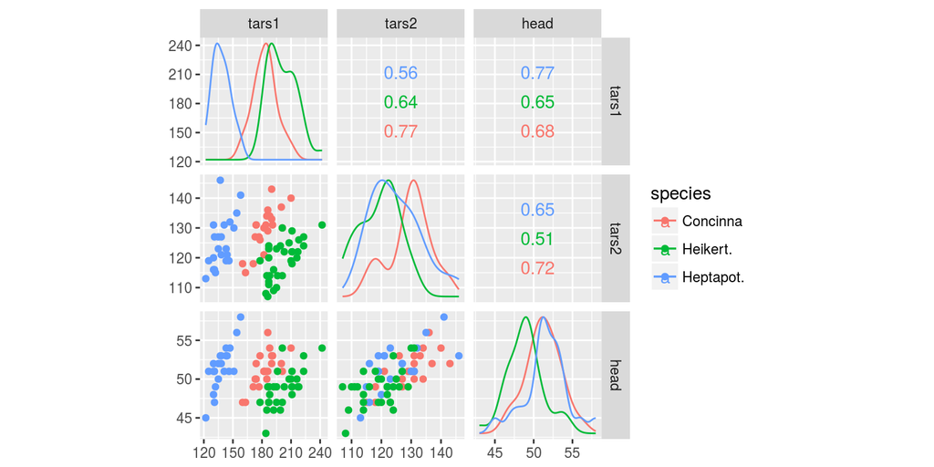

```r
data(flea)
ggscatmat(flea, columns = 2:4, color = "species")
```

Generalized pairs plot, any combination of types of plots

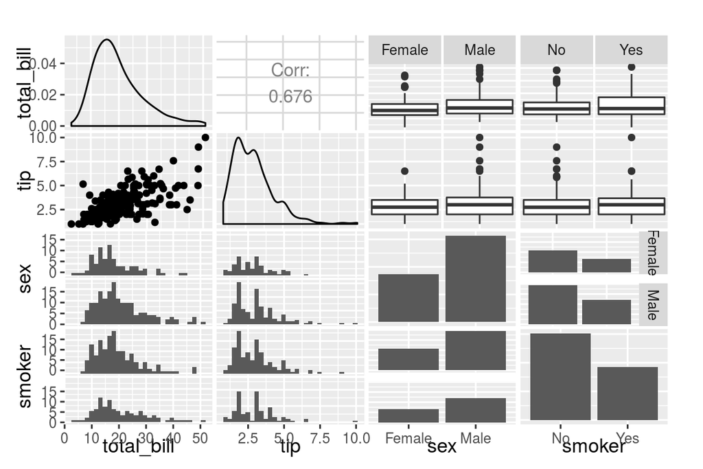

```r
data(tips, package = "reshape")
ggpairs(tips[, 1:4])
```

## For biological data

Brown, A. and Hudson, K. (2015) Developmental profiling of gene expression in soybean trifoliate leaves and cotyledons, GSE61857.

```r
coty <- read_delim("data/GSE61857_Cotyledon_normalized.txt.gz",
  delim="\t", col_types="cddddddddd",
  col_names=c("ID", "C_S1_R1", "C_S1_R2", "C_S1_R3",
  "C_S2_R1", "C_S2_R2", "C_S2_R3", "C_S3_R1", "C_S3_R2", "C_S3_R3"),
  skip=1)
coty <- as.data.frame(coty)
glimpse(coty)
```

```
#> Observations: 73,320
#> Variables: 10
#> $ ID      <chr> "Glyma0002s50.1", "Glyma0003s50.1", "Glyma0005s50.1", ...
#> $ C_S1_R1 <dbl> 4.9191791, 6.4923718, 0.8024444, 0.8024444, 6.9757606,...
#> $ C_S1_R2 <dbl> 5.2691071, 7.3523922, 1.8061819, 2.9021310, 6.6456986,...
#> $ C_S1_R3 <dbl> 4.8815068, 7.1775645, 2.4128941, 2.4128941, 6.8809924,...
#> $ C_S2_R1 <dbl> 5.1721597, 5.9841830, 3.5089265, 4.8005378, 6.5845203,...
#> $ C_S2_R2 <dbl> 4.8699195, 5.5523935, 2.4291909, 3.3457033, 6.3547777,...
#> $ C_S2_R3 <dbl> 5.4350790, 5.9200566, 2.0245709, 3.9300052, 5.4787713,...
#> $ C_S3_R1 <dbl> 5.0446299, 6.1727246, 0.8024444, 3.3644370, 6.0490685,...
#> $ C_S3_R2 <dbl> 5.4396835, 5.6460221, 1.6060994, 2.7942990, 6.0962895,...
#> $ C_S3_R3 <dbl> 4.7711860, 5.3257099, 0.8024444, 3.2556486, 5.5390583,...
```

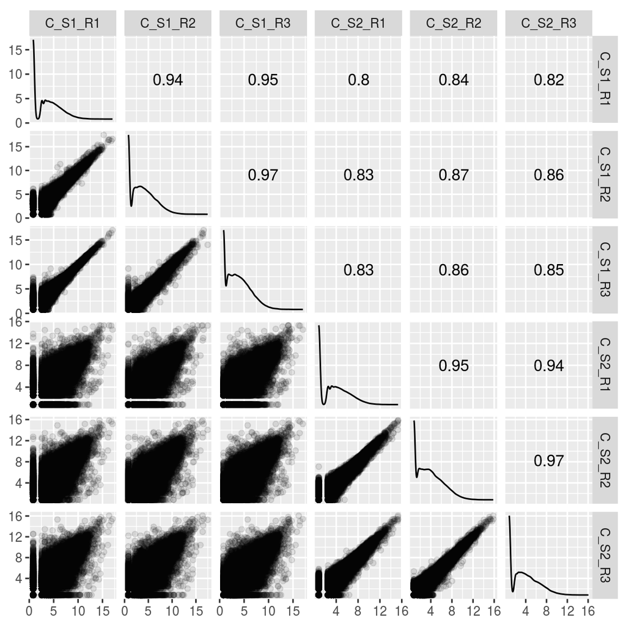

```r
ggscatmat(coty, columns=2:7, alpha=0.1)
```

Normalized data for the first 6 samples are shown.

## What we learn

- The replicates look more like each other than the developmental stage 1 vs 2. This is great data!
- There is a lot of variability in counts across stages, would indicate a lot of gene activity.
- There are a few genes that have some difference from one rep to another. These could be problematic when it comes to testing. To identify these it is easier to use interactive graphics - stay tuned for this tomorrow.

## Your turn

- Read the leaf data in from Brown and Hudson, and make a scatterplot matrix. (If it is too slow on your computer, sample the number of rows, to get a glimpse of the data to start.)
- Summarise what you learn about the data in a couple of sentences

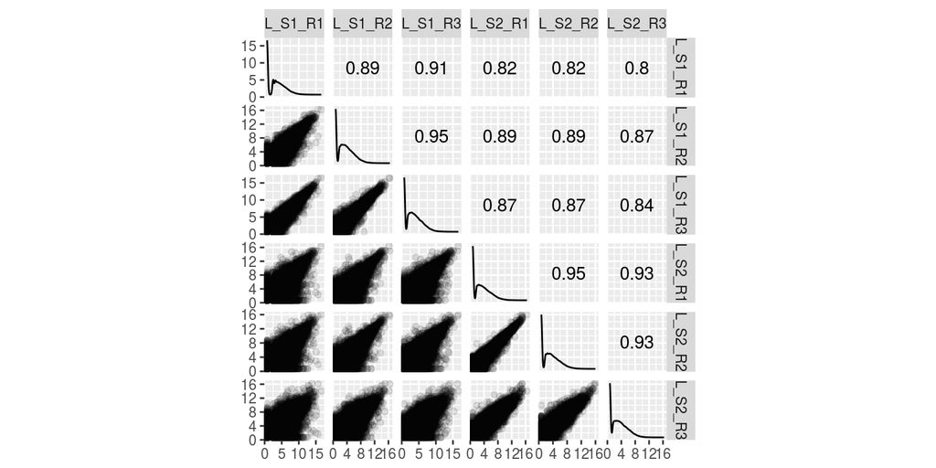

```r
leaf <- read_delim("data/GSE61857_Leaf_normalized.txt.gz",
                   delim="\t", col_types="cddddddddddddddd",
                   col_names=c("ID", "L_S1_R1", "L_S1_R2", "L_S1_R3",
                               "L_S2_R1", "L_S2_R2", "L_S2_R3",
                               "L_S3_R1", "L_S3_R2", "L_S3_R3",
                               "L_S4_R1", "L_S4_R2", "L_S4_R3",
                               "L_S5_R1", "L_S5_R2", "L_S5_R3"),
                   skip=1)
leaf <- as.data.frame(leaf)
ggscatmat(leaf, columns=2:7, alpha=0.1)
```

## Porcupine plots

Compare treatment vs reps. Focus on reps 1, 2 from stages 1 and 2.

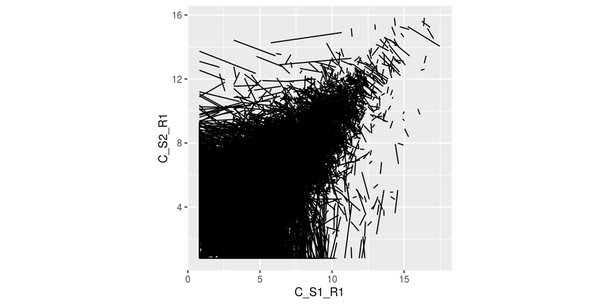

```r
sub <- coty %>% select(ID, C_S1_R1, C_S1_R2, C_S2_R1, C_S2_R2)
ggplot(sub, aes(x=C_S1_R1, xend=C_S1_R2, y=C_S2_R1, yend=C_S2_R2)) +
  geom_segment() +
  theme(aspect.ratio = 1)
```

The best prospects should be shortest lines further from the `X=Y`.

## Your turn

Make a porcupine plot for the first two reps of the first two developmental stages of the leaf data.

```r
names(leaf)
```

```
#>  [1] "ID"      "L_S1_R1" "L_S1_R2" "L_S1_R3" "L_S2_R1" "L_S2_R2" "L_S2_R3"
#>  [8] "L_S3_R1" "L_S3_R2" "L_S3_R3" "L_S4_R1" "L_S4_R2" "L_S4_R3" "L_S5_R1"
#> [15] "L_S5_R2" "L_S5_R3"
```

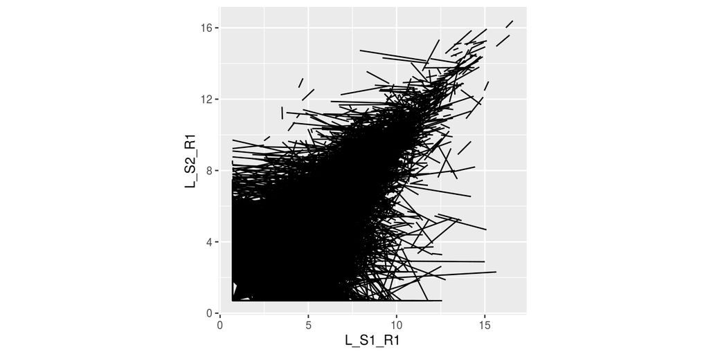

```r
leaf.sub <- leaf %>% select(ID, L_S1_R1, L_S1_R2, L_S2_R1, L_S2_R2)
ggplot(leaf.sub, aes(x=L_S1_R1, xend=L_S1_R2, y=L_S2_R1, yend=L_S2_R2)) +
  geom_segment() +
  theme(aspect.ratio = 1)
```

- Not as clean as the other data, because there are not as many short lines in the extremes (we want small rep differences and large treatment differences). - Many horizontal lines may imply some problem with the normalization between reps.

## Parallel coordinate plots

- Parallel coordinate plots, use parallel axes, and each observation is represented by a line tracing through the axes.
- They are useful for getting a sense of the multivariate shape of the data. You can typically read association, clustering and outliers from the plot.
- Can handle more variables than scatterplot matrices.

## Side-by-side boxplots to par coords

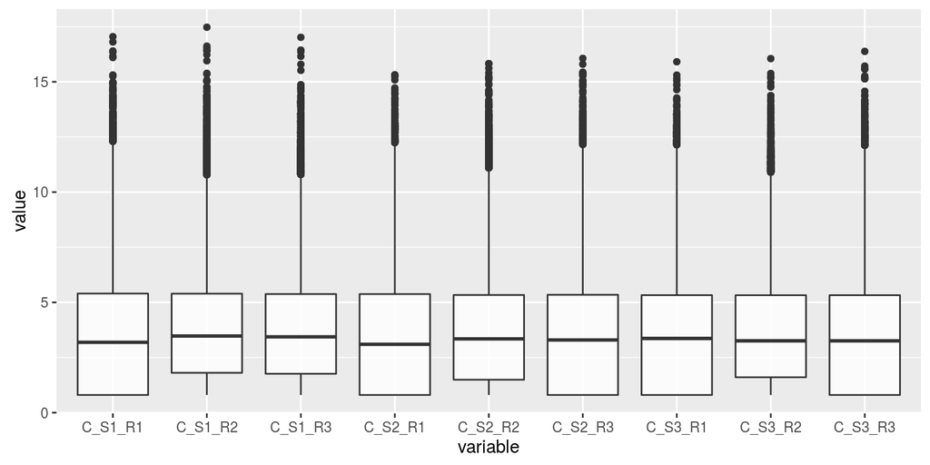

```r
ggparcoord(coty, columns=2:10, scale="globalminmax", boxplot=TRUE,
           alphaLines=0)
```

If the data is normalised well these should be identical boxplots, or very close to that. This is not quite what we see.

## Parallel coordinates, connect the dots

```r
ggparcoord(coty, columns=2:10, scale="globalminmax",
           alphaLines=0.1)
```

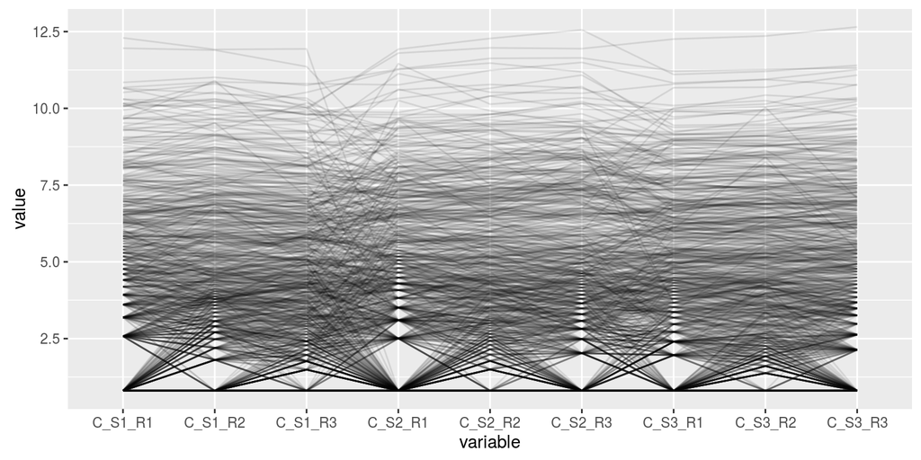

```r
ggparcoord(coty[sample(1:nrow(coty), 1000),],
           columns=2:10, scale="globalminmax",
           alphaLines=0.1)
```

## Scaling choices

- *std*: univariately, subtract mean and divide by standard deviation
- *robust*: univariately, subtract median and divide by median absolute deviation
- *uniminmax*: univariately, scale so the minimum of the variable is zero, and the maximum is one
- *globalminmax*: no scaling is done; the range of the graphs is defined by the global minimum and the global maximum

## Your turn

- Make parallel coordinate plots for the 9 samples of the leaf data
- Start with side-by-side boxplots, and then generate the lines
- Run the different scaling options to discover how they change the appearance of the plot

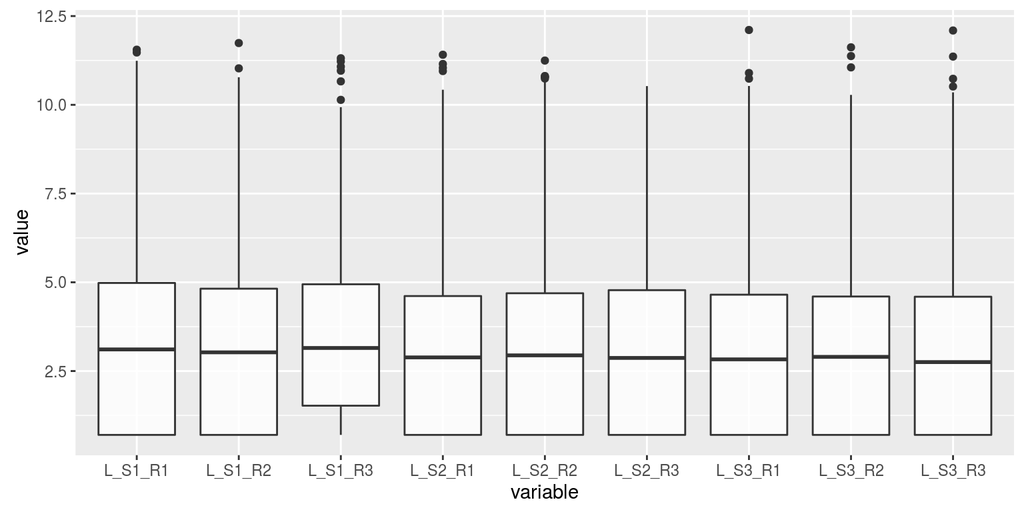

```r
leaf.sub <- leaf[sample(1:nrow(leaf), 1000), ]
ggparcoord(leaf.sub, columns=2:10, scale="globalminmax", boxplot=TRUE,
           alphaLines=0)
```

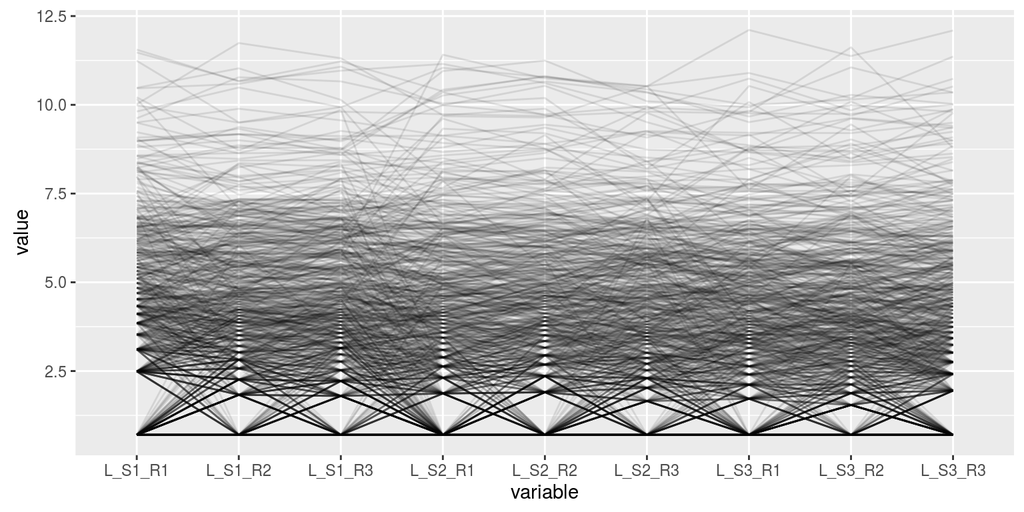

```r
ggparcoord(leaf.sub,
           columns=2:10, scale="globalminmax",
           alphaLines=0.1)
```

## Parcoords to interaction plots

Experiments are often displayed using interaction plots. These are similar to parallel coordinates, which display all the measurements, but interaction plots show one gene at a time.

Process the data, and then plot

```r
sub <- coty[sample(1:nrow(coty), 6),] %>%
  gather(sample, expr, -ID) %>%
  separate(sample, c("tissue", "stage", "rep")) %>%
  mutate(stage = as.numeric(substr(stage, 2, 2)))
sub.m <- sub %>% group_by(ID, stage) %>%
  summarise(expr = mean(expr))
```

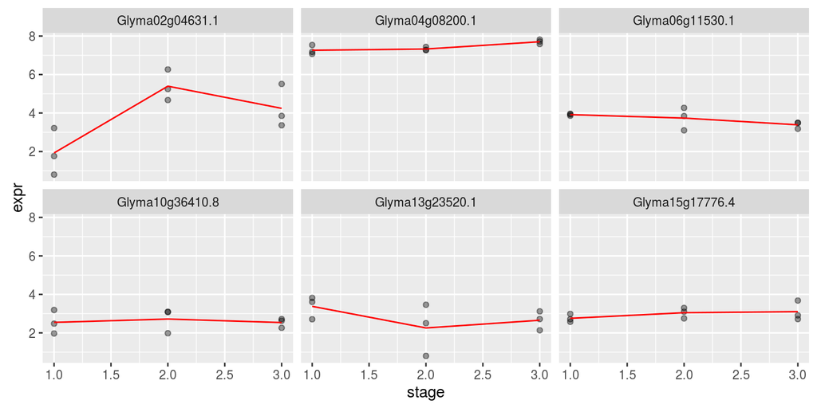

```r
ggplot(sub, aes(x=stage, y=expr)) + geom_point(alpha=0.4) +
  facet_wrap(~ID, ncol=3) +
  geom_line(data=sub.m, aes(x=stage, y=expr), colour="red")
```

## Your turn

Re-make the previous plot, by overlaying them in one plot, instead of faceting, and colour by the ID.

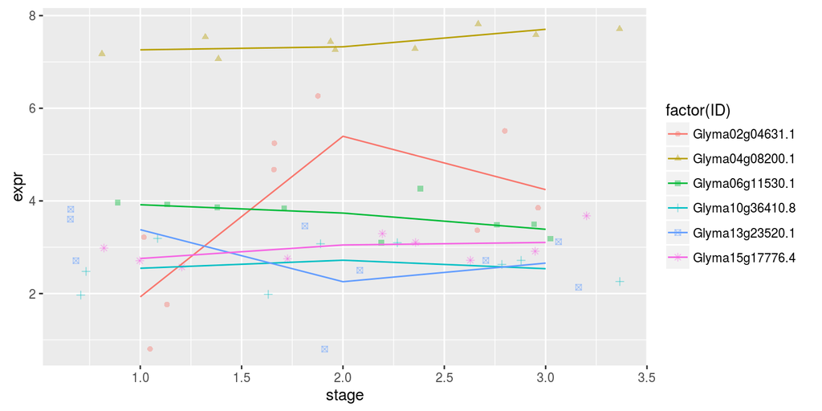

```r
ggplot(sub, aes(x=stage, y=expr, color=factor(ID), shape=factor(ID))) +
  geom_jitter(alpha=0.4) +
  geom_line(data=sub.m, aes(x=stage, y=expr))
```

## With significance testing

```r
d <- DGEList(counts = coty[,-1],
  group = c(rep("S1", 3), rep("S2", 3), rep("S3", 3)),
  genes = coty[,1])
d <- calcNormFactors(d)
d <- estimateCommonDisp(d)
d <- estimateTagwiseDisp(d)
de <- glmFit(d, design=matrix(c(rep(1, 9),
                                c(1,1,1,0,0,0,0,0,0),
                                c(0,0,0,1,1,1,0,0,0)),
                              ncol=3, byrow=F))
results <- glmLRT(de)
top10 <- as.data.frame(topTags(results, n=10))
```

## Plot

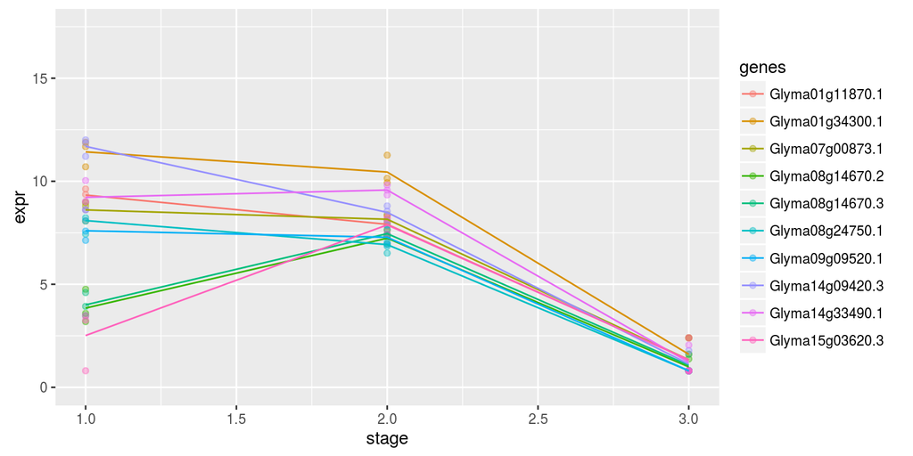

```r
sub <- coty %>%
  gather(sample, expr, -ID) %>%
  separate(sample, c("tissue", "stage", "rep")) %>%
  mutate(stage = as.numeric(substr(stage, 2, 2)))
top10 <- merge(top10, sub, by.x = "genes", by.y = "ID")
top10.m <- top10 %>% group_by(genes, stage) %>%
  summarise(expr = mean(expr))
ggplot(top10, aes(x=stage, y=expr, colour=genes)) +
  geom_point(alpha=0.4) + ylim(c(0,17.5)) +
  geom_line(data=top10.m, aes(x=stage, y=expr, colour=genes))
```

## Your turn

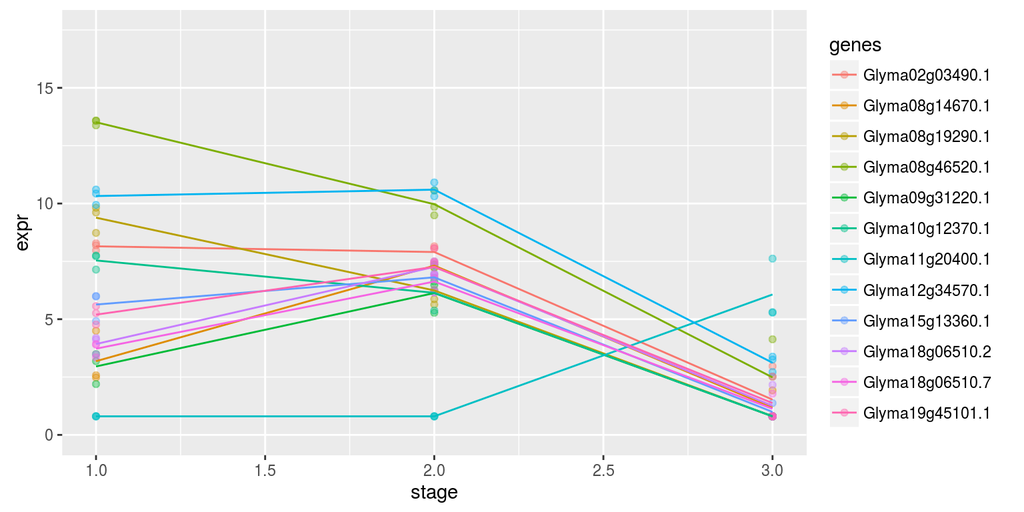

```r
top10 <- as.data.frame(topTags(results, n=24))[13:24,]
top10 <- merge(top10, sub, by.x = "genes", by.y = "ID")
top10.m <- top10 %>% group_by(genes, stage) %>%
  summarise(expr = mean(expr))
ggplot(top10, aes(x=stage, y=expr, colour=genes)) +
  geom_point(alpha=0.4) + ylim(c(0,17.5)) +
  geom_line(data=top10.m, aes(x=stage, y=expr, colour=genes))
```

## Extracting the significant genes

Just look pairwise for simplicity here.

```r
d <- DGEList(counts = coty[,2:7],
  group = c(rep("S1", 3), rep("S2", 3)),
  genes = coty[,1])
d <- calcNormFactors(d)
d <- estimateCommonDisp(d)
d <- estimateTagwiseDisp(d)
d <- estimateTrendedDisp(d)
de <- exactTest(d, pair=c("S1", "S2"), dispersion = "trended")
sig.tab <- de$table
sig.tab$genes <- coty$ID
sig.tab <- sig.tab %>% filter(PValue < 0.01)
```

```r
head(sig.tab)
```

```
#>       logFC   logCPM       PValue           genes
#> 1  2.476083 4.895799 1.298488e-05 Glyma01g00500.1
#> 2 -2.217651 4.086520 7.392236e-03 Glyma01g00890.1
#> 3  1.827047 4.576119 5.935482e-03 Glyma01g01770.1
#> 4  2.045754 4.334438 7.207139e-03 Glyma01g01770.2
#> 5  1.944447 4.644932 2.321160e-03 Glyma01g02360.1
#> 6  2.580681 4.243688 1.314291e-03 Glyma01g02670.1
```

```r
head(coty[,1:7])
```

```
#>               ID   C_S1_R1   C_S1_R2   C_S1_R3  C_S2_R1  C_S2_R2  C_S2_R3
#> 1 Glyma0002s50.1 4.9191791 5.2691071 4.8815068 5.172160 4.869919 5.435079
#> 2 Glyma0003s50.1 6.4923718 7.3523922 7.1775645 5.984183 5.552393 5.920057
#> 3 Glyma0005s50.1 0.8024444 1.8061819 2.4128941 3.508926 2.429191 2.024571
#> 4 Glyma0005s50.2 0.8024444 2.9021310 2.4128941 4.800538 3.345703 3.930005
#> 5 Glyma0006s50.1 6.9757606 6.6456986 6.8809924 6.584520 6.354778 5.478771
#> 6 Glyma0007s50.1 0.8024444 0.8024444 0.8024444 3.100206 1.495620 2.024571
```

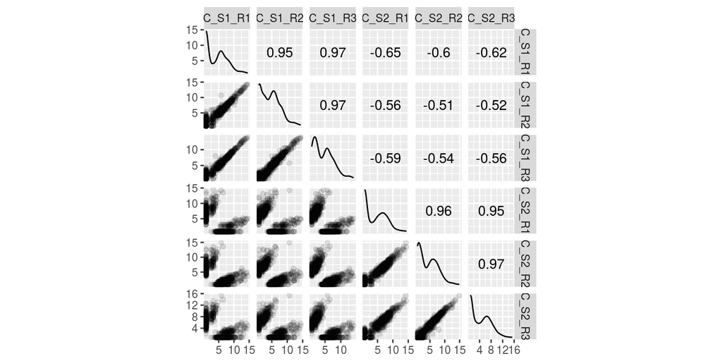

```r
sig.tab <- merge(sig.tab, coty[,1:7], by.x="genes", by.y="ID")
ggscatmat(sig.tab, columns=5:10, alpha=0.1)
```

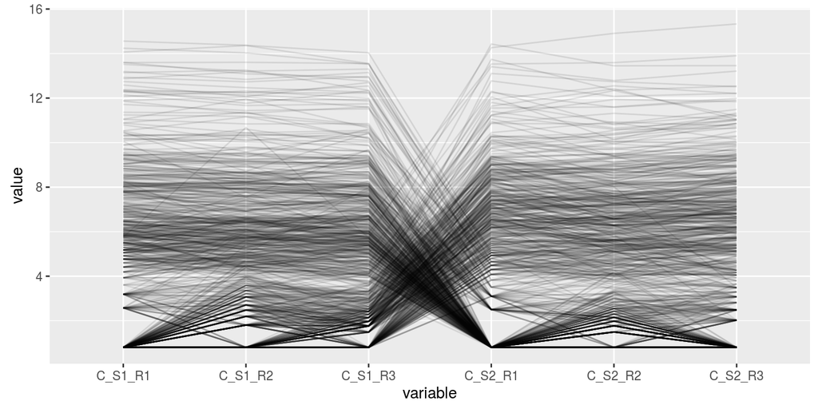

```r
ggparcoord(sig.tab, columns=5:10, scale="globalminmax",
           alphaLines=0.1)
```

## Share and share alike

This work is licensed under the Creative Commons Attribution-Noncommercial 3.0 United States License. To view a copy of this license, visit http://creativecommons.org/licenses/by-nc/ 3.0/us/ or send a letter to Creative Commons, 171 Second Street, Suite 300, San Francisco, California, 94105, USA.